# Logistic Regression and RCS Analysis Part 3

John Platt

2025-10-29

## Introduction

Ensuring assumptions are met beforehand and validating model fit, we conduct survey-weighted logistic regression stratified by the IRDSTNRV12 variable to examine the association between marijuana use and suicidal ideation. An unadjusted model without confounders will be conducted first, and subsequently, a fully adjusted model will be done.

## Logistic Regression Preparation

First, we get our dataset ready and check assumptions (don’t need to check for multicollinearity or non-linearity now) before performing logistic regression.

```r
#File -> New Project -> Set existing GitHub Repository as working directory with data2 as a subfolder outside the repository and the NSDUH_2023.Rdata file in the subfolder
#Load in the data
load("C:/Users/John Platt/OneDrive/data2/NSDUH_2021_2023.Rdata")
#Required packages:
#dplyr
library(dplyr) #data wrangling and manipulation
#Select a subset of the 2021-2023 NSDUH data that has the 27 necessary columns
data<-data %>% select(ANALWT2_C3,YEAR,VESTR_C,VEREP,IRSEX,CATAGE,NEWRACE2,EDUHIGHCAT,IRWRKSTAT18,IRHHSIZ2,IRPRVHLT,INCOME,IRALCFY,IRMJFY,IRCOCFY,IRCIGFM,IRNICVAP30N,IRHALLUCYFQ,IRALCBNG30D,SUTINPPY,IRDSTNRV12,IRDSTEFF12,IRIMPCONCN,IRSUICTHNK,IRAMDEYR,MHTINPPY,AMISUD5ANYO)
#Decoding of IRSEX column
data$IRSEX<-factor(data$IRSEX,
                    levels=c(1,2),labels=c('Male',"Female"))
#Decoding of EDUHIGHCAT column
data$EDUHIGHCAT<-factor(data$EDUHIGHCAT,
                    levels=c(1,2,3,4,5),
                    labels=c("Less high school","High school grad","Some coll/Assoc Dg","College graduate","12 to 17 year olds"))
#Decoding of IRPRVHLT column
data$IRPRVHLT<-factor(data$IRPRVHLT,
                    levels=c(1,2),
                    labels=c("Yes","No"))
#Decoding of IRHHSIZ2 column
data$IRHHSIZ2<-factor(data$IRHHSIZ2,
                    levels=c(1,2,3,4,5,6),
                    labels=c("One person in household","Two people in household","Three people in household","Four people in household","Five people in household","6 or more people in household"))
#Decoding of INCOME column
data$INCOME<-factor(data$INCOME,
                    levels=c(1,2,3,4),
                    labels=c("Less than $20,000","$20,000-$49,999","$50,000-$74,999","$75,000 or More"))
#Decoding of SUTINPPY column
data$SUTINPPY<-factor(data$SUTINPPY,
                    levels=c(0,1),
                    labels=c("No","Yes"))
#Decoding of IRDSTNRV12 column
data$IRDSTNRV12<-factor(data$IRDSTNRV12,
                    levels=c(1,2,3,4,5),
                    labels=c("All of the time","Most of the time","Some of the time","A little of the time","None of the time"))
#Decoding of IRDSTEFF12 column
data$IRDSTEFF12<-factor(data$IRDSTEFF12,
                        levels=c(1,2,3,4,5),
                        labels=c("All of the time","Most of the time","Some of the time","A little of the time","None of the time"))
#Decoding of IRIMPCONCN column
data$IRIMPCONCN<-factor(data$IRIMPCONCN,
                        levels=c(1,2,3,4),
                        labels=c("No difficulty","Mild difficultly","Moderate difficulty","Severe difficulty"))
#Decoding of IRSUICTHNK column
data$IRSUICTHNK<-factor(data$IRSUICTHNK,
                        levels=c(0,1),
                        labels=c("No","Yes"))
#Decoding of IRAMDEYR column
data$IRAMDEYR<-factor(data$IRAMDEYR,
                        levels=c(0,1),
                        labels=c("No","Yes"))
#Decoding of MHTINPPY column
data$MHTINPPY<-factor(data$MHTINPPY,
                        levels=c(0,1),
                        labels=c("No","Yes"))
#Decoding of AMISUD5ANYO column
#Note: missing values will be filtered out when examine the population subset: young adults
data$AMISUD5ANYO<-factor(data$AMISUD5ANYO,
                        levels=c(1,2,3,4),
                        labels=c("SUD only, no AMI","AMI only, no SUD","SUD and AMI","Neither SUD or AMI"))
#Replace missing values with 0 for substance use variables
zero_codes <- list(
  IRALCFY      = c(991, 993),
  IRCIGFM      = c(91, 93),
  IRMJFY       = c(991, 993),
  IRCOCFY      = c(991, 993),
  IRHALLUCYFQ  = c(991, 993),
  IRNICVAP30N  = c(91, 93),  # 91/93 here mean no use as well
  IRALCBNG30D  = c(91, 93)
)

for (v in names(zero_codes)) {
  data[[v]][data[[v]] %in% zero_codes[[v]]] <- 0
}
# Replace -9 (missing) with NA for these three variables only
vars_with_neg9 <- c("IRNICVAP30N", "SUTINPPY", "MHTINPPY")

for (v in vars_with_neg9) {
  if (v %in% names(data)) {
    data[[v]][data[[v]] == -9] <- NA
  }}
#Code suicidal ideation variable as numeric
data$IRSUICTHNK <- ifelse(data$IRSUICTHNK == "Yes", 1, ifelse(data$IRSUICTHNK == "No", 0, NA))
#Check data type of dataframe columns
str(data)
```

```
## tibble [173,808 × 27] (S3: tbl_df/tbl/data.frame)
##  $ ANALWT2_C3 : num [1:173808] 244.3 3903.3 155.6 3690.1 72.8 ...
##   ..- attr(*, "label")= chr "Analysis weights for three year data analysis"
##  $ YEAR       : chr [1:173808] "2021" "2021" "2021" "2021" ...
##   ..- attr(*, "label")= chr "YEAR IN WHICH DATA WAS COLLECTED"
##  $ VESTR_C    : num [1:173808] 40047 40037 40037 40045 40006 ...
##   ..- attr(*, "label")= chr "VARIANCE STRATUM"
##  $ VEREP      : num [1:173808] 1 2 2 2 1 2 2 1 2 2 ...
##   ..- attr(*, "label")= chr "VARIANCE PRIMARY SAMPLING UNIT"
##   ..- attr(*, "format.sas")= chr "Z"
##  $ IRSEX      : Factor w/ 2 levels "Male","Female": 2 1 2 1 1 1 1 2 2 2 ...
##  $ CATAGE     : num [1:173808] 3 4 2 4 2 4 2 4 1 2 ...
##   ..- attr(*, "label")= chr "RC-AGE CATEGORY"
##   ..- attr(*, "format.sas")= chr "CATAGEFMT"
##  $ NEWRACE2   : num [1:173808] 1 1 1 1 7 7 5 1 2 7 ...
##   ..- attr(*, "label")= chr "RC-RACE/HISPANICITY RECODE (7 LEVELS)"
##   ..- attr(*, "format.sas")= chr "NEWRACE2FMT"
##  $ EDUHIGHCAT : Factor w/ 5 levels "Less high school",..: 3 4 4 1 2 1 4 4 5 2 ...
##  $ IRWRKSTAT18: num [1:173808] 4 4 1 4 4 4 1 1 99 2 ...
##   ..- attr(*, "label")= chr "EMPLOYMENT STATUS 18+ - IMPUTATION REVISED"
##   ..- attr(*, "format.sas")= chr "IRWRKSTAT18FMT"
##  $ IRHHSIZ2   : Factor w/ 6 levels "One person in household",..: 2 2 2 3 1 5 5 2 5 4 ...
##  $ IRPRVHLT   : Factor w/ 2 levels "Yes","No": 2 1 1 2 2 1 1 1 2 2 ...
##  $ INCOME     : Factor w/ 4 levels "Less than $20,000",..: 1 4 2 2 1 3 4 3 1 1 ...
##  $ IRALCFY    : num [1:173808] 12 0 5 0 0 0 52 12 0 0 ...
##   ..- attr(*, "label")= chr "ALCOHOL FREQUENCY PAST YEAR - IMPUTATION REVISED"
##   ..- attr(*, "format.sas")= chr "IRALCFYFMT"
##  $ IRMJFY     : num [1:173808] 52 0 0 364 0 0 72 0 0 0 ...
##   ..- attr(*, "label")= chr "MARIJUANA FREQUENCY PAST YEAR - IMPUTATION REVISED"
##   ..- attr(*, "format.sas")= chr "IRMJFYFMT"
##  $ IRCOCFY    : num [1:173808] 0 0 0 0 0 0 0 0 0 0 ...
##   ..- attr(*, "label")= chr "COCAINE FREQUENCY PAST YEAR - IMPUTATION REVISED"
##   ..- attr(*, "format.sas")= chr "IRCOCFYFMT"
##  $ IRCIGFM    : num [1:173808] 7 0 0 30 0 30 1 0 0 0 ...
##   ..- attr(*, "label")= chr "CIG FREQUENCY PAST MONTH - IMPUTATION REVISED"
##   ..- attr(*, "format.sas")= chr "IRCIGFMFMT"
##  $ IRNICVAP30N: num [1:173808] NA NA NA NA NA NA NA NA NA NA ...
##   ..- attr(*, "label")= chr "NICOTINE VAPING FREQUENCY PAST MONTH - IMPUTATION REVISED"
##   ..- attr(*, "format.sas")= chr "IRNICVAP30NFMT"
##  $ IRHALLUCYFQ: num [1:173808] 0 0 0 0 0 0 0 0 0 0 ...
##   ..- attr(*, "label")= chr "HALL FREQUENCY PAST YEAR - IMPUTATION REVISED"
##   ..- attr(*, "format.sas")= chr "IRHALLUCYFQFMT"
##  $ IRALCBNG30D: num [1:173808] 0 0 0 0 0 0 0 0 0 0 ...
##   ..- attr(*, "label")= chr "BINGE ALCOHOL FREQUENCY PAST MONTH - IMPUTATION REVISED"
##   ..- attr(*, "format.sas")= chr "IRALCBNG30DFMT"
##  $ SUTINPPY   : Factor w/ 2 levels "No","Yes": NA NA NA NA NA NA NA NA NA NA ...
##  $ IRDSTNRV12 : Factor w/ 5 levels "All of the time",..: NA NA 1 NA NA NA 2 NA NA 3 ...
##  $ IRDSTEFF12 : Factor w/ 5 levels "All of the time",..: NA NA 3 NA NA NA 1 NA NA 3 ...
##  $ IRIMPCONCN : Factor w/ 4 levels "No difficulty",..: 1 NA 2 3 NA NA 3 2 NA 2 ...
##  $ IRSUICTHNK : num [1:173808] 0 0 0 0 0 0 0 1 NA 0 ...
##  $ IRAMDEYR   : Factor w/ 2 levels "No","Yes": 1 1 1 1 1 1 2 1 NA 1 ...
##  $ MHTINPPY   : Factor w/ 2 levels "No","Yes": NA NA NA NA NA NA NA NA NA NA ...
##  $ AMISUD5ANYO: Factor w/ 4 levels "SUD only, no AMI",..: 4 4 2 3 4 4 2 2 NA 4 ...
```

```r
#Required packages:
#fastDummies
library(fastDummies) #Dummy variable creation
#Convert nominal variables into dummy variables and drop reference dummy to avoid "dummy variable trap"
data <- dummy_cols(data, select_columns = c("NEWRACE2","IRWRKSTAT18"), remove_first_dummy = TRUE, remove_selected_columns = TRUE)
head(data)
```

```
## # A tibble: 6 × 35
##   ANALWT2_C3 YEAR  VESTR_C VEREP IRSEX  CATAGE EDUHIGHCAT      IRHHSIZ2 IRPRVHLT
##        <dbl> <chr>   <dbl> <dbl> <fct>   <dbl> <fct>           <fct>    <fct>
## 1      244.  2021    40047     1 Female      3 Some coll/Asso… Two peo… No
## 2     3903.  2021    40037     2 Male        4 College gradua… Two peo… Yes
## 3      156.  2021    40037     2 Female      2 College gradua… Two peo… Yes
## 4     3690.  2021    40045     2 Male        4 Less high scho… Three p… No
## 5       72.8 2021    40006     1 Male        2 High school gr… One per… No
## 6    29909.  2021    40041     2 Male        4 Less high scho… Five pe… Yes
## # ℹ 26 more variables: INCOME <fct>, IRALCFY <dbl>, IRMJFY <dbl>,
## #   IRCOCFY <dbl>, IRCIGFM <dbl>, IRNICVAP30N <dbl>, IRHALLUCYFQ <dbl>,
## #   IRALCBNG30D <dbl>, SUTINPPY <fct>, IRDSTNRV12 <fct>, IRDSTEFF12 <fct>,
## #   IRIMPCONCN <fct>, IRSUICTHNK <dbl>, IRAMDEYR <fct>, MHTINPPY <fct>,
## #   AMISUD5ANYO <fct>, NEWRACE2_2 <int>, NEWRACE2_3 <int>, NEWRACE2_4 <int>,
## #   NEWRACE2_5 <int>, NEWRACE2_6 <int>, NEWRACE2_7 <int>, IRWRKSTAT18_2 <int>,
## #   IRWRKSTAT18_3 <int>, IRWRKSTAT18_4 <int>, IRWRKSTAT18_99 <int>
```

```r
#Convert illicit substance use variables into categories
data$IRMJFY2 <- cut(data$IRMJFY, breaks = 4, #number of categories
                    labels = c("0-90", "90-180", "180-270", "270-360"), include.lowest = TRUE)
data$IRCOCFY2 <- cut(data$IRCOCFY, breaks = 4, # number of categories
                     labels = c("0-90", "90-180", "180-270", "270-360"), include.lowest = TRUE)
data$IRHALLUCYFQ2 <- cut(data$IRHALLUCYFQ, breaks = 4, # number of categories
                         labels = c("0-90", "90-180", "180-270", "270-360"), include.lowest = TRUE)
str(data)
```

```
## tibble [173,808 × 38] (S3: tbl_df/tbl/data.frame)
##  $ ANALWT2_C3    : num [1:173808] 244.3 3903.3 155.6 3690.1 72.8 ...
##   ..- attr(*, "label")= chr "Analysis weights for three year data analysis"
##  $ YEAR          : chr [1:173808] "2021" "2021" "2021" "2021" ...
##   ..- attr(*, "label")= chr "YEAR IN WHICH DATA WAS COLLECTED"
##  $ VESTR_C       : num [1:173808] 40047 40037 40037 40045 40006 ...
##   ..- attr(*, "label")= chr "VARIANCE STRATUM"
##  $ VEREP         : num [1:173808] 1 2 2 2 1 2 2 1 2 2 ...
##   ..- attr(*, "label")= chr "VARIANCE PRIMARY SAMPLING UNIT"
##   ..- attr(*, "format.sas")= chr "Z"
##  $ IRSEX         : Factor w/ 2 levels "Male","Female": 2 1 2 1 1 1 1 2 2 2 ...
##  $ CATAGE        : num [1:173808] 3 4 2 4 2 4 2 4 1 2 ...
##   ..- attr(*, "label")= chr "RC-AGE CATEGORY"
##   ..- attr(*, "format.sas")= chr "CATAGEFMT"
##  $ EDUHIGHCAT    : Factor w/ 5 levels "Less high school",..: 3 4 4 1 2 1 4 4 5 2 ...
##  $ IRHHSIZ2      : Factor w/ 6 levels "One person in household",..: 2 2 2 3 1 5 5 2 5 4 ...
##  $ IRPRVHLT      : Factor w/ 2 levels "Yes","No": 2 1 1 2 2 1 1 1 2 2 ...
##  $ INCOME        : Factor w/ 4 levels "Less than $20,000",..: 1 4 2 2 1 3 4 3 1 1 ...
##  $ IRALCFY       : num [1:173808] 12 0 5 0 0 0 52 12 0 0 ...
##   ..- attr(*, "label")= chr "ALCOHOL FREQUENCY PAST YEAR - IMPUTATION REVISED"
##   ..- attr(*, "format.sas")= chr "IRALCFYFMT"
##  $ IRMJFY        : num [1:173808] 52 0 0 364 0 0 72 0 0 0 ...
##   ..- attr(*, "label")= chr "MARIJUANA FREQUENCY PAST YEAR - IMPUTATION REVISED"
##   ..- attr(*, "format.sas")= chr "IRMJFYFMT"
##  $ IRCOCFY       : num [1:173808] 0 0 0 0 0 0 0 0 0 0 ...
##   ..- attr(*, "label")= chr "COCAINE FREQUENCY PAST YEAR - IMPUTATION REVISED"
##   ..- attr(*, "format.sas")= chr "IRCOCFYFMT"
##  $ IRCIGFM       : num [1:173808] 7 0 0 30 0 30 1 0 0 0 ...
##   ..- attr(*, "label")= chr "CIG FREQUENCY PAST MONTH - IMPUTATION REVISED"
##   ..- attr(*, "format.sas")= chr "IRCIGFMFMT"
##  $ IRNICVAP30N   : num [1:173808] NA NA NA NA NA NA NA NA NA NA ...
##   ..- attr(*, "label")= chr "NICOTINE VAPING FREQUENCY PAST MONTH - IMPUTATION REVISED"
##   ..- attr(*, "format.sas")= chr "IRNICVAP30NFMT"
##  $ IRHALLUCYFQ   : num [1:173808] 0 0 0 0 0 0 0 0 0 0 ...
##   ..- attr(*, "label")= chr "HALL FREQUENCY PAST YEAR - IMPUTATION REVISED"
##   ..- attr(*, "format.sas")= chr "IRHALLUCYFQFMT"
##  $ IRALCBNG30D   : num [1:173808] 0 0 0 0 0 0 0 0 0 0 ...
##   ..- attr(*, "label")= chr "BINGE ALCOHOL FREQUENCY PAST MONTH - IMPUTATION REVISED"
##   ..- attr(*, "format.sas")= chr "IRALCBNG30DFMT"
##  $ SUTINPPY      : Factor w/ 2 levels "No","Yes": NA NA NA NA NA NA NA NA NA NA ...
##  $ IRDSTNRV12    : Factor w/ 5 levels "All of the time",..: NA NA 1 NA NA NA 2 NA NA 3 ...
##  $ IRDSTEFF12    : Factor w/ 5 levels "All of the time",..: NA NA 3 NA NA NA 1 NA NA 3 ...
##  $ IRIMPCONCN    : Factor w/ 4 levels "No difficulty",..: 1 NA 2 3 NA NA 3 2 NA 2 ...
##  $ IRSUICTHNK    : num [1:173808] 0 0 0 0 0 0 0 1 NA 0 ...
##  $ IRAMDEYR      : Factor w/ 2 levels "No","Yes": 1 1 1 1 1 1 2 1 NA 1 ...
##  $ MHTINPPY      : Factor w/ 2 levels "No","Yes": NA NA NA NA NA NA NA NA NA NA ...
##  $ AMISUD5ANYO   : Factor w/ 4 levels "SUD only, no AMI",..: 4 4 2 3 4 4 2 2 NA 4 ...
##  $ NEWRACE2_2    : int [1:173808] 0 0 0 0 0 0 0 0 1 0 ...
##  $ NEWRACE2_3    : int [1:173808] 0 0 0 0 0 0 0 0 0 0 ...
##  $ NEWRACE2_4    : int [1:173808] 0 0 0 0 0 0 0 0 0 0 ...
##  $ NEWRACE2_5    : int [1:173808] 0 0 0 0 0 0 1 0 0 0 ...
##  $ NEWRACE2_6    : int [1:173808] 0 0 0 0 0 0 0 0 0 0 ...
##  $ NEWRACE2_7    : int [1:173808] 0 0 0 0 1 1 0 0 0 1 ...
##  $ IRWRKSTAT18_2 : int [1:173808] 0 0 0 0 0 0 0 0 0 1 ...
##  $ IRWRKSTAT18_3 : int [1:173808] 0 0 0 0 0 0 0 0 0 0 ...
##  $ IRWRKSTAT18_4 : int [1:173808] 1 1 0 1 1 1 0 0 0 0 ...
##  $ IRWRKSTAT18_99: int [1:173808] 0 0 0 0 0 0 0 0 1 0 ...
##  $ IRMJFY2       : Factor w/ 4 levels "0-90","90-180",..: 1 1 1 4 1 1 1 1 1 1 ...
##  $ IRCOCFY2      : Factor w/ 4 levels "0-90","90-180",..: 1 1 1 1 1 1 1 1 1 1 ...
##  $ IRHALLUCYFQ2  : Factor w/ 4 levels "0-90","90-180",..: 1 1 1 1 1 1 1 1 1 1 ...
```

```r
#Install survey package
library(survey) #Library for survey design
options(survey.lonely.psu = "adjust")  #common & documented choice to adjust variance if there are single psus within stratum
#Specify survey design
des <- svydesign(
  id      = ~VEREP, #PSU/cluster id
  strata  = ~VESTR_C, #variance strata
  weights = ~ANALWT2_C3, #analysis weight
  data    = data, #2021-2023 NSDUH dataframe
  nest = TRUE
)
#Check strata, PSUs, and effective sample size for each subgroup (subgroup 1)
young_adults1 <- subset(des, CATAGE == 2 & (IRDSTNRV12=="All of the time" | IRDSTNRV12=="Most of the time"))
#Number of unique strata and PSUs in the subpopulation
length(unique(young_adults1$variables$VESTR_C))
```

```
## [1] 50
```

```r
length(unique(young_adults1$variables$VEREP))
```

```
## [1] 2
```

```r
#Compute effective sample size
w <- weights(young_adults1)
ess <- (sum(w)^2) / sum(w^2)
print(ess)
```

```
## [1] 3304.542
```

```r
#Subgroup2
young_adults2 <- subset(des, CATAGE == 2 & (IRDSTNRV12=="Some of the time" | IRDSTNRV12=="A little of the time" | IRDSTNRV12=="None of the time"))
#Number of unique strata and PSUs in the subpopulation
length(unique(young_adults2$variables$VESTR_C))
```

```
## [1] 50
```

```r
length(unique(young_adults2$variables$VEREP))
```

```
## [1] 2
```

```r
#Compute effective sample size
w <- weights(young_adults2)
ess <- (sum(w)^2) / sum(w^2)
print(ess)
```

```
## [1] 2551.969
```

# Logistic Regression 1

We do our adjusted and unadjusted logistic regression models for subgroup 1.

```r
#Fit unadjusted logistic regression model between marijuana use and suicidal ideation
fit <- svyglm(IRSUICTHNK ~ IRMJFY2, design = young_adults1, family = quasibinomial())
#Coefficients → ORs with 95% CIs
co <- coef(fit) #Beta coefficients
vc <- vcov(fit) #Variance-covariance matrix
se <- sqrt(diag(vc)) #Standard error
z  <- qnorm(0.975) #Z-score for 95% confidence interval
#Create dataframe with estimates
est <- data.frame(
  term = names(co), #Model variables
  beta = co, #Beta coefficient
  se   = se, #Standard eror
  OR   = exp(co), #Odds ratio
  LCL  = exp(co - z*se), #Odds ratio lower confidence level
  UCL  = exp(co + z*se), #Odds ratio upper confidence level
  p    = 2*pnorm(-abs(co/se)) #P-value for odds ratio
)
#Drop the intercept row when reporting
subset(est, term != "(Intercept)")
```

```
##                          term      beta        se       OR      LCL      UCL
## IRMJFY290-180   IRMJFY290-180 0.4510429 0.1800201 1.569949 1.103194 2.234183
## IRMJFY2180-270 IRMJFY2180-270 0.5247111 0.1408184 1.689971 1.282373 2.227122
## IRMJFY2270-360 IRMJFY2270-360 0.5980931 0.1029445 1.818648 1.486353 2.225231
##                           p
## IRMJFY290-180  1.222734e-02
## IRMJFY2180-270 1.944223e-04
## IRMJFY2270-360 6.252590e-09
```

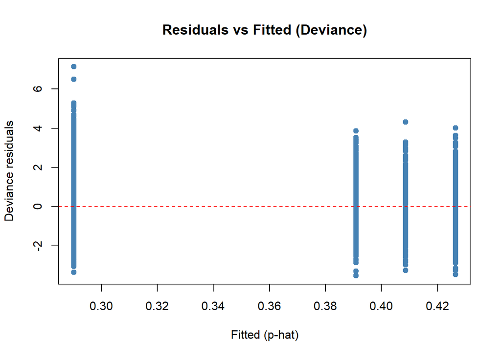

```r
res_dev <- residuals(fit, type = "deviance")
plot(fitted(fit), res_dev, xlab="Fitted (p-hat)", ylab="Deviance residuals",
     main="Residuals vs Fitted (Deviance)", pch=19, col="steelblue")
abline(h=0, lty=2, col="red")
```

```r
#Fit unadjusted logistic regression model between marijuana use and suicidal ideation
fit <- svyglm(IRSUICTHNK ~ IRSEX, design = young_adults1, family = quasibinomial())
#Coefficients → ORs with 95% CIs
co <- coef(fit) #Beta coefficients
vc <- vcov(fit) #Variance-covariance matrix
se <- sqrt(diag(vc)) #Standard error
z  <- qnorm(0.975) #Z-score for 95% confidence interval
#Create dataframe with estimates
est <- data.frame(
  term = names(co), #Model variables
  beta = co, #Beta coefficient
  se   = se, #Standard eror
  OR   = exp(co), #Odds ratio
  LCL  = exp(co - z*se), #Odds ratio lower confidence level
  UCL  = exp(co + z*se), #Odds ratio upper confidence level
  p    = 2*pnorm(-abs(co/se)) #P-value for odds ratio
)
#Drop the intercept row when reporting
subset(est, term != "(Intercept)")
```

```
##                    term        beta         se        OR       LCL      UCL
## IRSEXFemale IRSEXFemale -0.01289763 0.07337769 0.9871852 0.8549475 1.139877
##                     p
## IRSEXFemale 0.8604743
```

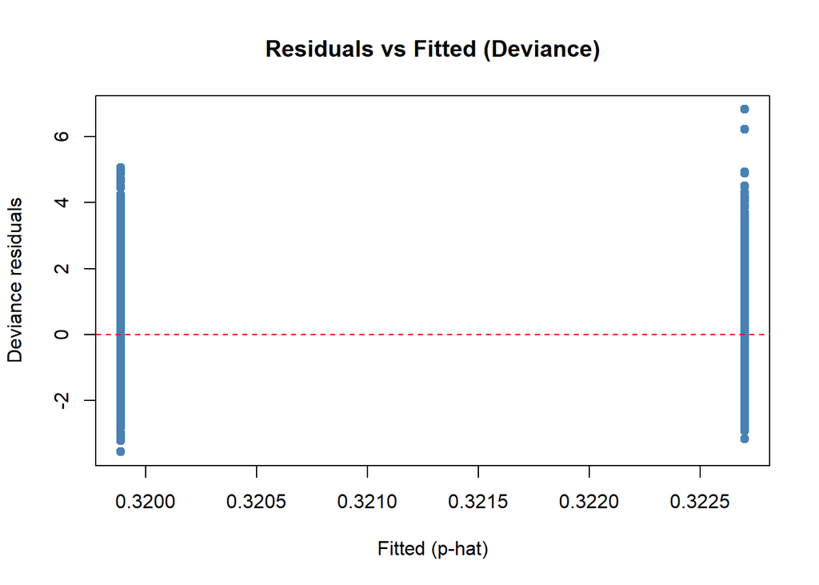

```r
res_dev <- residuals(fit, type = "deviance")
plot(fitted(fit), res_dev, xlab="Fitted (p-hat)", ylab="Deviance residuals",
     main="Residuals vs Fitted (Deviance)", pch=19, col="steelblue")
abline(h=0, lty=2, col="red")
```

```r
#Fit unadjusted logistic regression model between marijuana use and suicidal ideation
fit <- svyglm(IRSUICTHNK ~ EDUHIGHCAT, design = young_adults1, family = quasibinomial())
#Coefficients → ORs with 95% CIs
co <- coef(fit) #Beta coefficients
vc <- vcov(fit) #Variance-covariance matrix
se <- sqrt(diag(vc)) #Standard error
z  <- qnorm(0.975) #Z-score for 95% confidence interval
#Create dataframe with estimates
est <- data.frame(
  term = names(co), #Model variables
  beta = co, #Beta coefficient
  se   = se, #Standard eror
  OR   = exp(co), #Odds ratio
  LCL  = exp(co - z*se), #Odds ratio lower confidence level
  UCL  = exp(co + z*se), #Odds ratio upper confidence level
  p    = 2*pnorm(-abs(co/se)) #P-value for odds ratio
)
#Drop the intercept row when reporting
subset(est, term != "(Intercept)")
```

```
##                                                      term       beta        se
## EDUHIGHCATHigh school grad     EDUHIGHCATHigh school grad -0.2354629 0.1211041
## EDUHIGHCATSome coll/Assoc Dg EDUHIGHCATSome coll/Assoc Dg -0.4124382 0.1393404
## EDUHIGHCATCollege graduate     EDUHIGHCATCollege graduate -1.0102450 0.1619499
##                                     OR       LCL       UCL            p
## EDUHIGHCATHigh school grad   0.7902050 0.6232406 1.0018986 5.185914e-02
## EDUHIGHCATSome coll/Assoc Dg 0.6620341 0.5038179 0.8699356 3.077059e-03
## EDUHIGHCATCollege graduate   0.3641297 0.2650966 0.5001591 4.431729e-10
```

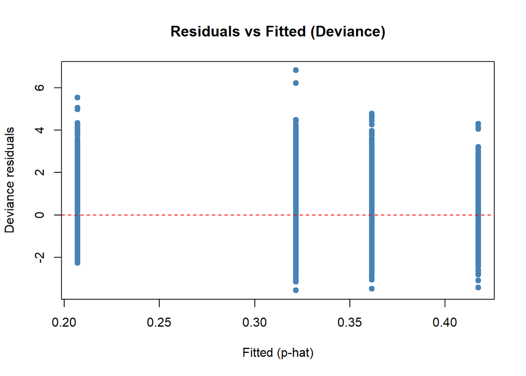

```r
res_dev <- residuals(fit, type = "deviance")
plot(fitted(fit), res_dev, xlab="Fitted (p-hat)", ylab="Deviance residuals",
     main="Residuals vs Fitted (Deviance)", pch=19, col="steelblue")
abline(h=0, lty=2, col="red")
```

```r
#Fit unadjusted logistic regression model between marijuana use and suicidal ideation
fit <- svyglm(IRSUICTHNK ~ IRPRVHLT, design = young_adults1, family = quasibinomial())
#Coefficients → ORs with 95% CIs
co <- coef(fit) #Beta coefficients
vc <- vcov(fit) #Variance-covariance matrix
se <- sqrt(diag(vc)) #Standard error
z  <- qnorm(0.975) #Z-score for 95% confidence interval
#Create dataframe with estimates
est <- data.frame(
  term = names(co), #Model variables
  beta = co, #Beta coefficient
  se   = se, #Standard eror
  OR   = exp(co), #Odds ratio
  LCL  = exp(co - z*se), #Odds ratio lower confidence level
  UCL  = exp(co + z*se), #Odds ratio upper confidence level
  p    = 2*pnorm(-abs(co/se)) #P-value for odds ratio
)
#Drop the intercept row when reporting
subset(est, term != "(Intercept)")
```

```
##                  term      beta         se       OR      LCL      UCL
## IRPRVHLTNo IRPRVHLTNo 0.1517475 0.07638826 1.163866 1.002031 1.351839
##                     p
## IRPRVHLTNo 0.04697459
```

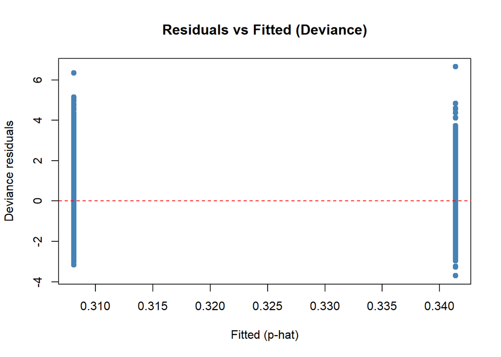

```r
res_dev <- residuals(fit, type = "deviance")
plot(fitted(fit), res_dev, xlab="Fitted (p-hat)", ylab="Deviance residuals",
     main="Residuals vs Fitted (Deviance)", pch=19, col="steelblue")
abline(h=0, lty=2, col="red")
```

```r
#Fit unadjusted logistic regression model between marijuana use and suicidal ideation
fit <- svyglm(IRSUICTHNK ~ IRHHSIZ2, design = young_adults1, family = quasibinomial())
#Coefficients → ORs with 95% CIs
co <- coef(fit) #Beta coefficients
vc <- vcov(fit) #Variance-covariance matrix
se <- sqrt(diag(vc)) #Standard error
z  <- qnorm(0.975) #Z-score for 95% confidence interval
#Create dataframe with estimates
est <- data.frame(
  term = names(co), #Model variables
  beta = co, #Beta coefficient
  se   = se, #Standard eror
  OR   = exp(co), #Odds ratio
  LCL  = exp(co - z*se), #Odds ratio lower confidence level
  UCL  = exp(co + z*se), #Odds ratio upper confidence level
  p    = 2*pnorm(-abs(co/se)) #P-value for odds ratio
)
#Drop the intercept row when reporting
subset(est, term != "(Intercept)")
```

```
##                                                                        term
## IRHHSIZ2Two people in household             IRHHSIZ2Two people in household
## IRHHSIZ2Three people in household         IRHHSIZ2Three people in household
## IRHHSIZ2Four people in household           IRHHSIZ2Four people in household
## IRHHSIZ2Five people in household           IRHHSIZ2Five people in household
## IRHHSIZ26 or more people in household IRHHSIZ26 or more people in household
##                                              beta        se        OR       LCL
## IRHHSIZ2Two people in household       -0.21012617 0.1504111 0.8104820 0.6035499
## IRHHSIZ2Three people in household     -0.02825966 0.1372252 0.9721359 0.7428834
## IRHHSIZ2Four people in household      -0.26058458 0.1567930 0.7706010 0.5667181
## IRHHSIZ2Five people in household      -0.23352914 0.1825840 0.7917345 0.5535588
## IRHHSIZ26 or more people in household -0.16348898 0.1691859 0.8491759 0.6095177
##                                            UCL          p
## IRHHSIZ2Two people in household       1.088362 0.16240994
## IRHHSIZ2Three people in household     1.272135 0.83684067
## IRHHSIZ2Four people in household      1.047833 0.09651976
## IRHHSIZ2Five people in household      1.132388 0.20088905
## IRHHSIZ26 or more people in household 1.183066 0.33388049
```

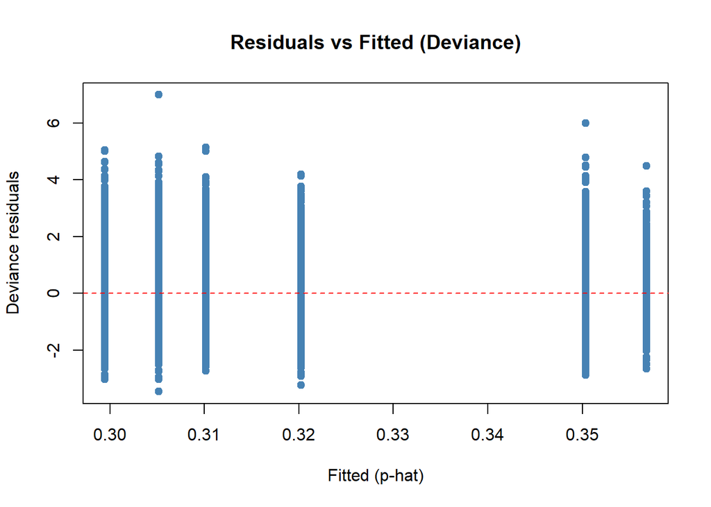

```r
res_dev <- residuals(fit, type = "deviance")
plot(fitted(fit), res_dev, xlab="Fitted (p-hat)", ylab="Deviance residuals",
     main="Residuals vs Fitted (Deviance)", pch=19, col="steelblue")
abline(h=0, lty=2, col="red")
```

```r
#Fit unadjusted logistic regression model between marijuana use and suicidal ideation
fit <- svyglm(IRSUICTHNK ~ INCOME, design = young_adults1, family = quasibinomial())
#Coefficients → ORs with 95% CIs
co <- coef(fit) #Beta coefficients
vc <- vcov(fit) #Variance-covariance matrix
se <- sqrt(diag(vc)) #Standard error
z  <- qnorm(0.975) #Z-score for 95% confidence interval
#Create dataframe with estimates
est <- data.frame(
  term = names(co), #Model variables
  beta = co, #Beta coefficient
  se   = se, #Standard eror
  OR   = exp(co), #Odds ratio
  LCL  = exp(co - z*se), #Odds ratio lower confidence level
  UCL  = exp(co + z*se), #Odds ratio upper confidence level
  p    = 2*pnorm(-abs(co/se)) #P-value for odds ratio
)
#Drop the intercept row when reporting
subset(est, term != "(Intercept)")
```

```
##                                        term         beta         se        OR
## INCOME$20,000-$49,999 INCOME$20,000-$49,999 -0.184460019 0.09687525 0.8315532
## INCOME$50,000-$74,999 INCOME$50,000-$74,999 -0.009614822 0.12657593 0.9904313
## INCOME$75,000 or More INCOME$75,000 or More -0.263684704 0.09416864 0.7682157
##                             LCL       UCL           p
## INCOME$20,000-$49,999 0.6877485 1.0054266 0.056897343
## INCOME$50,000-$74,999 0.7728277 1.2693049 0.939450206
## INCOME$75,000 or More 0.6387438 0.9239313 0.005108156
```

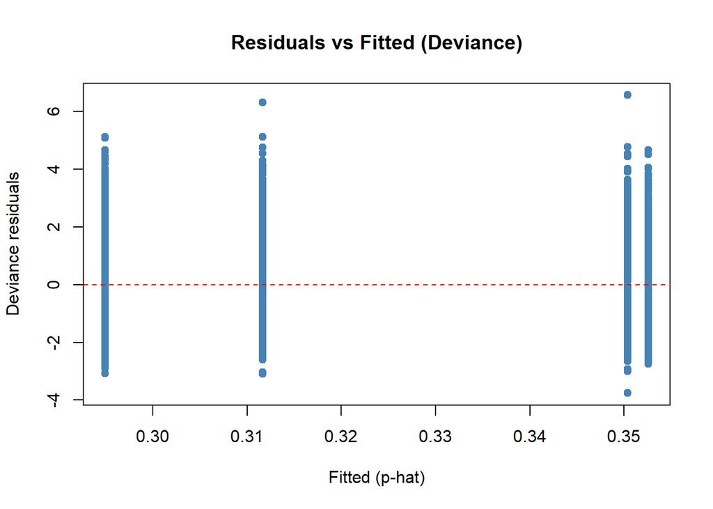

```r
res_dev <- residuals(fit, type = "deviance")
plot(fitted(fit), res_dev, xlab="Fitted (p-hat)", ylab="Deviance residuals",
     main="Residuals vs Fitted (Deviance)", pch=19, col="steelblue")
abline(h=0, lty=2, col="red")
```

```r
#Fit unadjusted logistic regression model between alcohol use and suicidal ideation
fit <- svyglm(IRSUICTHNK ~ IRALCFY, design = young_adults1, family = quasibinomial())
#Coefficients → ORs with 95% CIs
co <- coef(fit) #Beta coefficients
vc <- vcov(fit) #Variance-covariance matrix
se <- sqrt(diag(vc)) #Standard error
z  <- qnorm(0.975) #Z-score for 95% confidence interval
#Create dataframe with estimates
est <- data.frame(
  term = names(co), #Model variables
  beta = co, #Beta coefficient
  se   = se, #Standard eror
  OR   = exp(co), #Odds ratio
  LCL  = exp(co - z*se), #Odds ratio lower confidence level
  UCL  = exp(co + z*se), #Odds ratio upper confidence level
  p    = 2*pnorm(-abs(co/se)) #P-value for odds ratio
)
#Drop the intercept row when reporting
subset(est, term != "(Intercept)")
```

```
##            term        beta           se       OR      LCL      UCL
## IRALCFY IRALCFY 0.002226752 0.0004245916 1.002229 1.001396 1.003064
##                    p
## IRALCFY 1.567446e-07
```

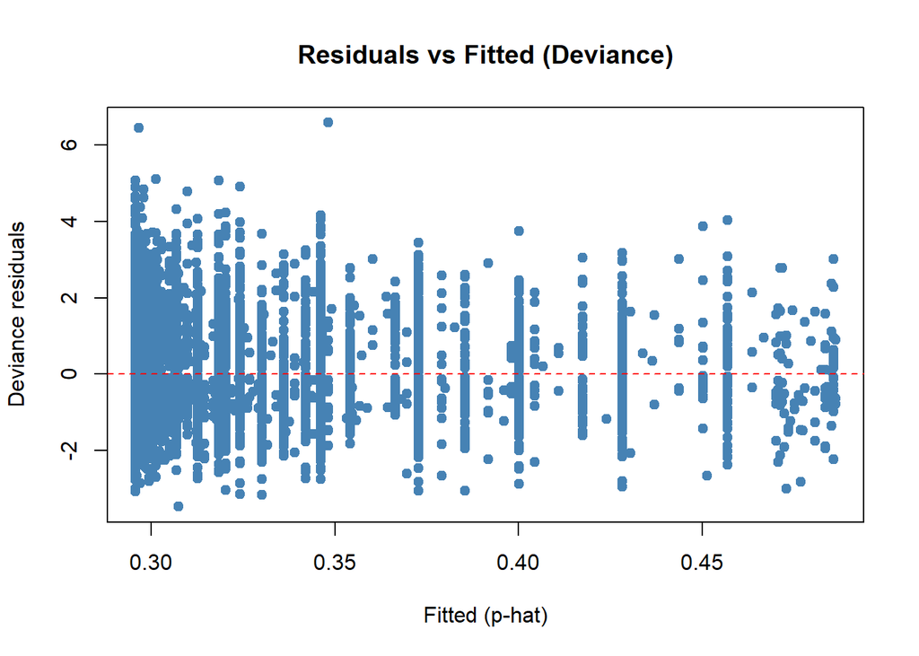

```r
res_dev <- residuals(fit, type = "deviance")
plot(fitted(fit), res_dev, xlab="Fitted (p-hat)", ylab="Deviance residuals",
     main="Residuals vs Fitted (Deviance)", pch=19, col="steelblue")
abline(h=0, lty=2, col="red")
```

```r
#Fit unadjusted logistic regression model between marijuana use and suicidal ideation
fit <- svyglm(IRSUICTHNK ~ IRCIGFM, design = young_adults1, family = quasibinomial())
#Coefficients → ORs with 95% CIs
co <- coef(fit) #Beta coefficients
vc <- vcov(fit) #Variance-covariance matrix
se <- sqrt(diag(vc)) #Standard error
z  <- qnorm(0.975) #Z-score for 95% confidence interval
#Create dataframe with estimates
est <- data.frame(
  term = names(co), #Model variables
  beta = co, #Beta coefficient
  se   = se, #Standard eror
  OR   = exp(co), #Odds ratio
  LCL  = exp(co - z*se), #Odds ratio lower confidence level
  UCL  = exp(co + z*se), #Odds ratio upper confidence level
  p    = 2*pnorm(-abs(co/se)) #P-value for odds ratio
)
#Drop the intercept row when reporting
subset(est, term != "(Intercept)")
```

```
##            term       beta          se       OR      LCL      UCL            p
## IRCIGFM IRCIGFM 0.02793394 0.005086942 1.028328 1.018126 1.038632 3.989816e-08
```

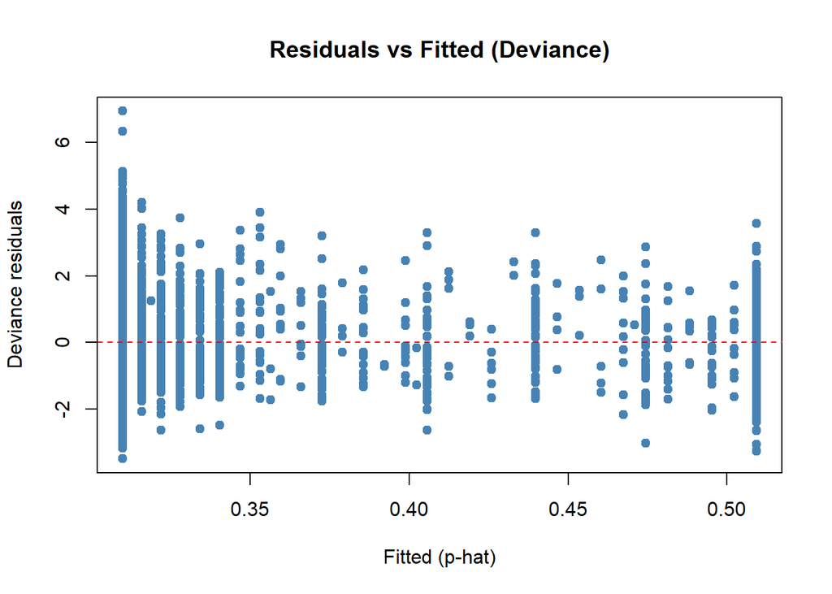

```r
res_dev <- residuals(fit, type = "deviance")
plot(fitted(fit), res_dev, xlab="Fitted (p-hat)", ylab="Deviance residuals",
     main="Residuals vs Fitted (Deviance)", pch=19, col="steelblue")
abline(h=0, lty=2, col="red")
```

```r
#Fit unadjusted logistic regression model between marijuana use and suicidal ideation
fit <- svyglm(IRSUICTHNK ~ IRNICVAP30N, design = young_adults1, family = quasibinomial())
#Coefficients → ORs with 95% CIs
co <- coef(fit) #Beta coefficients
vc <- vcov(fit) #Variance-covariance matrix
se <- sqrt(diag(vc)) #Standard error
z  <- qnorm(0.975) #Z-score for 95% confidence interval
#Create dataframe with estimates
est <- data.frame(
  term = names(co), #Model variables
  beta = co, #Beta coefficient
  se   = se, #Standard eror
  OR   = exp(co), #Odds ratio
  LCL  = exp(co - z*se), #Odds ratio lower confidence level
  UCL  = exp(co + z*se), #Odds ratio upper confidence level
  p    = 2*pnorm(-abs(co/se)) #P-value for odds ratio
)
#Drop the intercept row when reporting
subset(est, term != "(Intercept)")
```

```
##                    term       beta          se       OR     LCL      UCL
## IRNICVAP30N IRNICVAP30N 0.01838064 0.004018659 1.018551 1.01056 1.026605
##                        p
## IRNICVAP30N 4.788996e-06
```

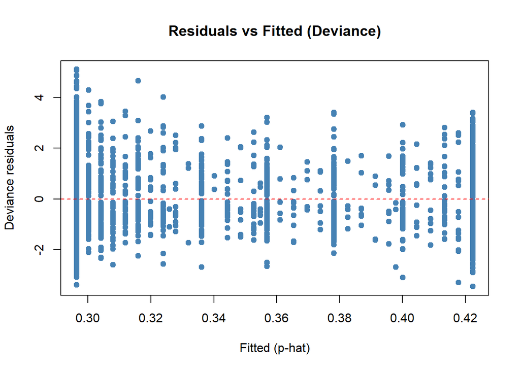

```r
res_dev <- residuals(fit, type = "deviance")
plot(fitted(fit), res_dev, xlab="Fitted (p-hat)", ylab="Deviance residuals",
     main="Residuals vs Fitted (Deviance)", pch=19, col="steelblue")
abline(h=0, lty=2, col="red")
```

```r
#Fit unadjusted logistic regression model between marijuana use and suicidal ideation
fit <- svyglm(IRSUICTHNK ~ IRALCBNG30D, design = young_adults1, family = quasibinomial())
#Coefficients → ORs with 95% CIs
co <- coef(fit) #Beta coefficients
vc <- vcov(fit) #Variance-covariance matrix
se <- sqrt(diag(vc)) #Standard error
z  <- qnorm(0.975) #Z-score for 95% confidence interval
#Create dataframe with estimates
est <- data.frame(
  term = names(co), #Model variables
  beta = co, #Beta coefficient
  se   = se, #Standard eror
  OR   = exp(co), #Odds ratio
  LCL  = exp(co - z*se), #Odds ratio lower confidence level
  UCL  = exp(co + z*se), #Odds ratio upper confidence level
  p    = 2*pnorm(-abs(co/se)) #P-value for odds ratio
)
#Drop the intercept row when reporting
subset(est, term != "(Intercept)")
```

```
##                    term       beta         se       OR      LCL      UCL
## IRALCBNG30D IRALCBNG30D 0.03786808 0.01058034 1.038594 1.017279 1.060356
##                        p
## IRALCBNG30D 0.0003447811
```

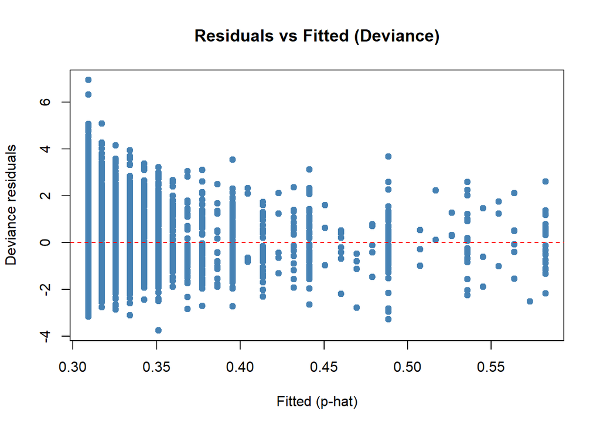

```r
res_dev <- residuals(fit, type = "deviance")
plot(fitted(fit), res_dev, xlab="Fitted (p-hat)", ylab="Deviance residuals",
     main="Residuals vs Fitted (Deviance)", pch=19, col="steelblue")
abline(h=0, lty=2, col="red")
```

```r
#Fit unadjusted logistic regression model between marijuana use and suicidal ideation
fit <- svyglm(IRSUICTHNK ~ SUTINPPY, design = young_adults1, family = quasibinomial())
#Coefficients → ORs with 95% CIs
co <- coef(fit) #Beta coefficients
vc <- vcov(fit) #Variance-covariance matrix
se <- sqrt(diag(vc)) #Standard error
z  <- qnorm(0.975) #Z-score for 95% confidence interval
#Create dataframe with estimates
est <- data.frame(
  term = names(co), #Model variables
  beta = co, #Beta coefficient
  se   = se, #Standard eror
  OR   = exp(co), #Odds ratio
  LCL  = exp(co - z*se), #Odds ratio lower confidence level
  UCL  = exp(co + z*se), #Odds ratio upper confidence level
  p    = 2*pnorm(-abs(co/se)) #P-value for odds ratio
)
#Drop the intercept row when reporting
subset(est, term != "(Intercept)")
```

```
##                    term     beta        se       OR      LCL      UCL
## SUTINPPYYes SUTINPPYYes 1.162363 0.2042343 3.197482 2.142711 4.771474
##                        p
## SUTINPPYYes 1.260575e-08
```

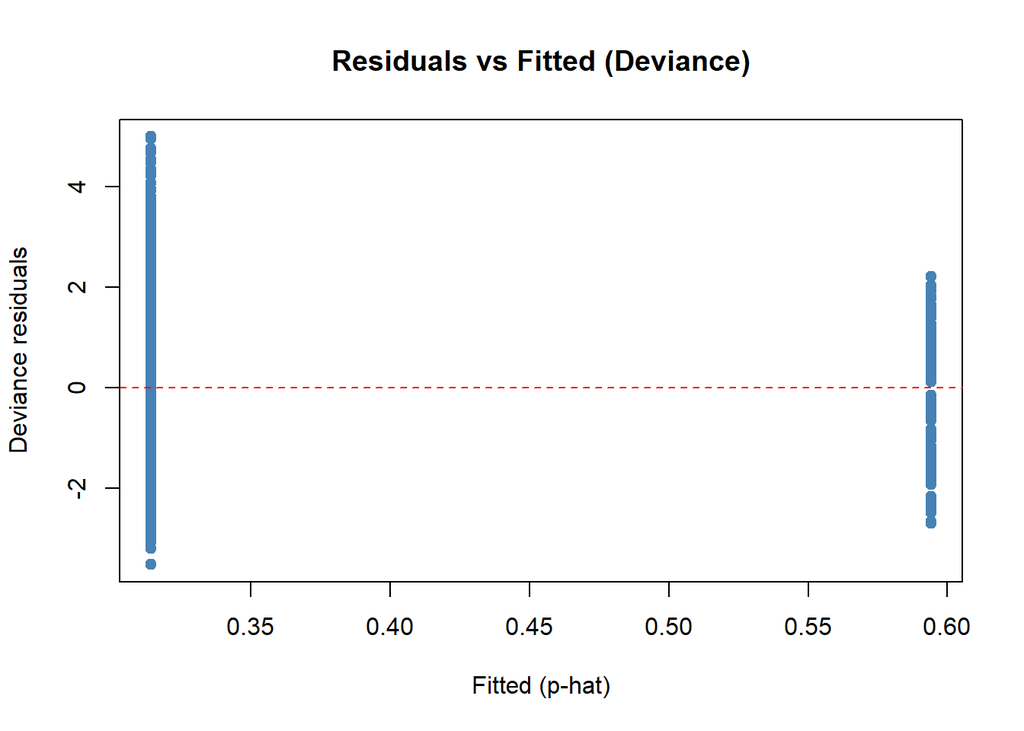

```r
res_dev <- residuals(fit, type = "deviance")
plot(fitted(fit), res_dev, xlab="Fitted (p-hat)", ylab="Deviance residuals",
     main="Residuals vs Fitted (Deviance)", pch=19, col="steelblue")
abline(h=0, lty=2, col="red")
```

```r
#Fit unadjusted logistic regression model between marijuana use and suicidal ideation
fit <- svyglm(IRSUICTHNK ~ IRIMPCONCN, design = young_adults1, family = quasibinomial())
#Coefficients → ORs with 95% CIs
co <- coef(fit) #Beta coefficients
vc <- vcov(fit) #Variance-covariance matrix
se <- sqrt(diag(vc)) #Standard error
z  <- qnorm(0.975) #Z-score for 95% confidence interval
#Create dataframe with estimates
est <- data.frame(
  term = names(co), #Model variables
  beta = co, #Beta coefficient
  se   = se, #Standard eror
  OR   = exp(co), #Odds ratio
  LCL  = exp(co - z*se), #Odds ratio lower confidence level
  UCL  = exp(co + z*se), #Odds ratio upper confidence level
  p    = 2*pnorm(-abs(co/se)) #P-value for odds ratio
)
#Drop the intercept row when reporting
subset(est, term != "(Intercept)")
```

```
##                                                        term      beta        se
## IRIMPCONCNMild difficultly       IRIMPCONCNMild difficultly 0.1637217 0.1492942
## IRIMPCONCNModerate difficulty IRIMPCONCNModerate difficulty 0.5016157 0.1477888
## IRIMPCONCNSevere difficulty     IRIMPCONCNSevere difficulty 1.1061131 0.1494146
##                                     OR       LCL      UCL            p
## IRIMPCONCNMild difficultly    1.177886 0.8790711 1.578276 2.727996e-01
## IRIMPCONCNModerate difficulty 1.651387 1.2360923 2.206210 6.884461e-04
## IRIMPCONCNSevere difficulty   3.022587 2.2552615 4.050986 1.331621e-13
```

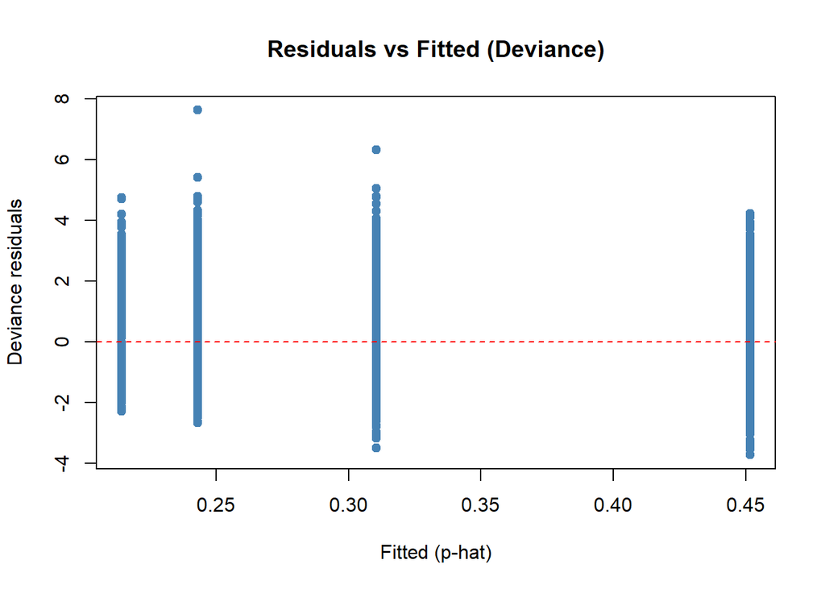

```r
res_dev <- residuals(fit, type = "deviance")
plot(fitted(fit), res_dev, xlab="Fitted (p-hat)", ylab="Deviance residuals",
     main="Residuals vs Fitted (Deviance)", pch=19, col="steelblue")
abline(h=0, lty=2, col="red")
```

```r
#Fit unadjusted logistic regression model between marijuana use and suicidal ideation
fit <- svyglm(IRSUICTHNK ~ NEWRACE2_2 + NEWRACE2_3 + NEWRACE2_4 + NEWRACE2_5 + NEWRACE2_6 + NEWRACE2_7, design = young_adults1, family = quasibinomial())
#Coefficients → ORs with 95% CIs
co <- coef(fit) #Beta coefficients
vc <- vcov(fit) #Variance-covariance matrix
se <- sqrt(diag(vc)) #Standard error
z  <- qnorm(0.975) #Z-score for 95% confidence interval
#Create dataframe with estimates
est <- data.frame(
  term = names(co), #Model variables
  beta = co, #Beta coefficient
  se   = se, #Standard eror
  OR   = exp(co), #Odds ratio
  LCL  = exp(co - z*se), #Odds ratio lower confidence level
  UCL  = exp(co + z*se), #Odds ratio upper confidence level
  p    = 2*pnorm(-abs(co/se)) #P-value for odds ratio
)
#Drop the intercept row when reporting
subset(est, term != "(Intercept)")
```

```
##                  term        beta        se        OR       LCL      UCL
## NEWRACE2_2 NEWRACE2_2  0.16878107 0.1218266 1.1838609 0.9323988 1.503141
## NEWRACE2_3 NEWRACE2_3  0.91607358 0.3736825 2.4994572 1.2016185 5.199060
## NEWRACE2_4 NEWRACE2_4  0.84324787 0.5628534 2.3239025 0.7711097 7.003572
## NEWRACE2_5 NEWRACE2_5  0.11008654 0.1810508 1.1163747 0.7828873 1.591918
## NEWRACE2_6 NEWRACE2_6  0.20278496 0.1677632 1.2248091 0.8815929 1.701644
## NEWRACE2_7 NEWRACE2_7 -0.06873517 0.1069763 0.9335739 0.7569904 1.151349
##                     p
## NEWRACE2_2 0.16592393
## NEWRACE2_3 0.01422717
## NEWRACE2_4 0.13409013
## NEWRACE2_5 0.54315946
## NEWRACE2_6 0.22675616
## NEWRACE2_7 0.52053081
```

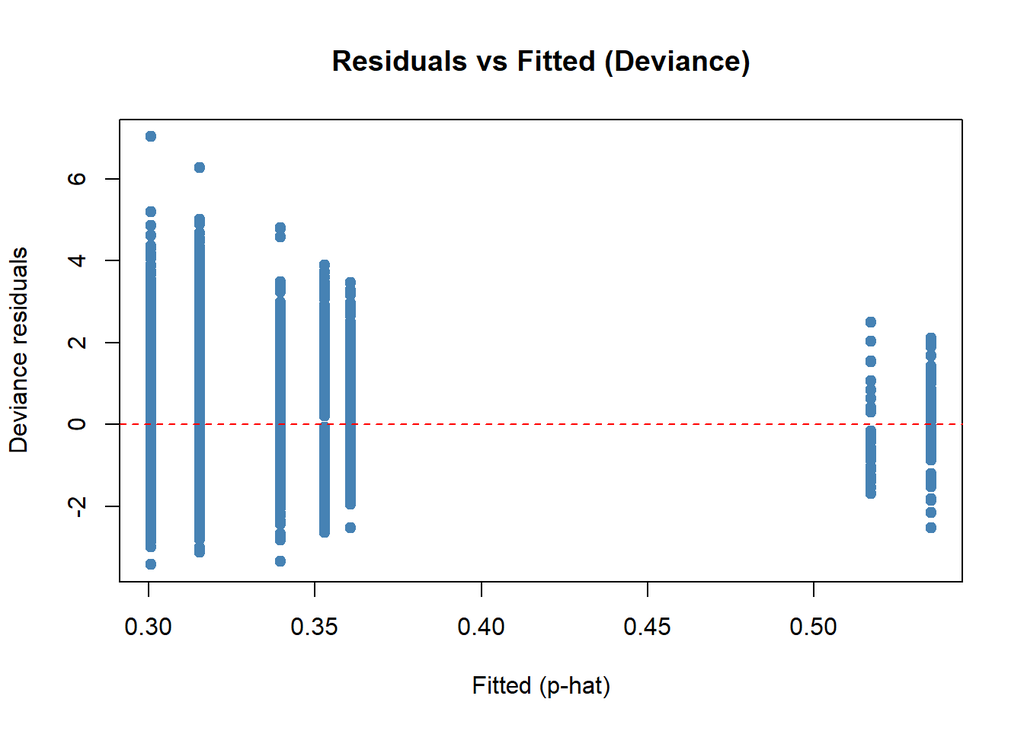

```r
res_dev <- residuals(fit, type = "deviance")
plot(fitted(fit), res_dev, xlab="Fitted (p-hat)", ylab="Deviance residuals",
     main="Residuals vs Fitted (Deviance)", pch=19, col="steelblue")
abline(h=0, lty=2, col="red")
```

```r
#Fit unadjusted logistic regression model between marijuana use and suicidal ideation
fit <- svyglm(IRSUICTHNK ~ IRWRKSTAT18_2 + IRWRKSTAT18_3 + IRWRKSTAT18_4, design = young_adults1, family = quasibinomial())
#Coefficients → ORs with 95% CIs
co <- coef(fit) #Beta coefficients
vc <- vcov(fit) #Variance-covariance matrix
se <- sqrt(diag(vc)) #Standard error
z  <- qnorm(0.975) #Z-score for 95% confidence interval
#Create dataframe with estimates
est <- data.frame(
  term = names(co), #Model variables
  beta = co, #Beta coefficient
  se   = se, #Standard eror
  OR   = exp(co), #Odds ratio
  LCL  = exp(co - z*se), #Odds ratio lower confidence level
  UCL  = exp(co + z*se), #Odds ratio upper confidence level
  p    = 2*pnorm(-abs(co/se)) #P-value for odds ratio
)
#Drop the intercept row when reporting
subset(est, term != "(Intercept)")
```

```
##                        term        beta         se        OR       LCL      UCL
## IRWRKSTAT18_2 IRWRKSTAT18_2 -0.02384596 0.09236754 0.9764361 0.8147426 1.170219
## IRWRKSTAT18_3 IRWRKSTAT18_3  0.24448531 0.12996399 1.2769639 0.9898128 1.647419
## IRWRKSTAT18_4 IRWRKSTAT18_4 -0.19518414 0.10658100 0.8226832 0.6675913 1.013805
##                        p
## IRWRKSTAT18_2 0.79628045
## IRWRKSTAT18_3 0.05994781
## IRWRKSTAT18_4 0.06705248
```

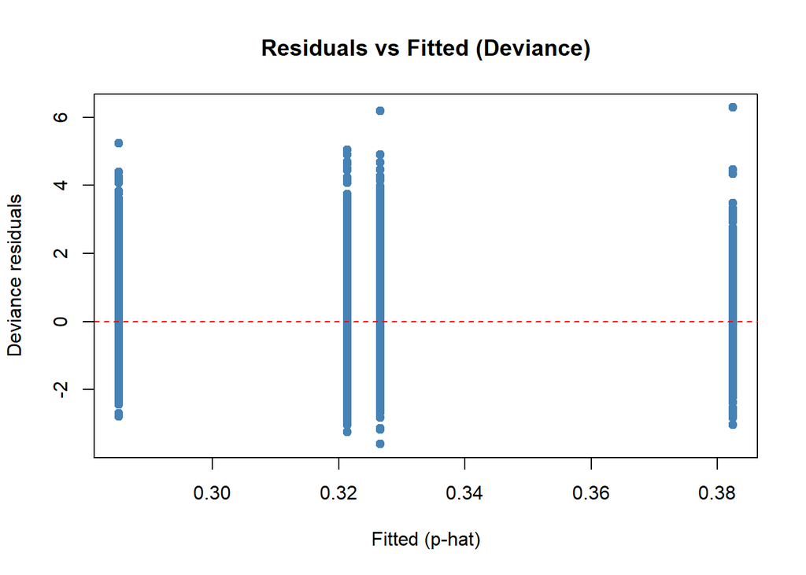

```r
res_dev <- residuals(fit, type = "deviance")
plot(fitted(fit), res_dev, xlab="Fitted (p-hat)", ylab="Deviance residuals",
     main="Residuals vs Fitted (Deviance)", pch=19, col="steelblue")
abline(h=0, lty=2, col="red")
```

```r
#Fit the adjusted PML logistic regression (quasibinomial for robust SEs)
fit <- svyglm(
  IRSUICTHNK ~ IRMJFY2 + IRSEX + EDUHIGHCAT + IRPRVHLT + IRHHSIZ2 + IRNICVAP30N + SUTINPPY + IRCIGFM + IRIMPCONCN +  IRALCFY + IRALCBNG30D +
               NEWRACE2_2 + NEWRACE2_3 + NEWRACE2_4 + NEWRACE2_5 + NEWRACE2_6 + NEWRACE2_7 +
               IRWRKSTAT18_2 + IRWRKSTAT18_3 + IRWRKSTAT18_4,
  design = young_adults1,
  family = quasibinomial()
)
#Coefficients → ORs with 95% CIs
co <- coef(fit)
vc <- vcov(fit)
se <- sqrt(diag(vc))
z  <- qnorm(0.975)
#Create dataframe with coefficients
est <- data.frame(
  term = names(co),
  beta = co,
  se   = se,
  OR   = exp(co),
  LCL  = exp(co - z*se),
  UCL  = exp(co + z*se),
  p    = 2*pnorm(-abs(co/se))
)
#Drop the intercept row when reporting
subset(est, term != "(Intercept)")
```

```
##                                                                        term
## IRMJFY290-180                                                 IRMJFY290-180
## IRMJFY2180-270                                               IRMJFY2180-270
## IRMJFY2270-360                                               IRMJFY2270-360
## IRSEXFemale                                                     IRSEXFemale
## EDUHIGHCATHigh school grad                       EDUHIGHCATHigh school grad
## EDUHIGHCATSome coll/Assoc Dg                   EDUHIGHCATSome coll/Assoc Dg
## EDUHIGHCATCollege graduate                       EDUHIGHCATCollege graduate
## IRPRVHLTNo                                                       IRPRVHLTNo
## IRHHSIZ2Two people in household             IRHHSIZ2Two people in household
## IRHHSIZ2Three people in household         IRHHSIZ2Three people in household
## IRHHSIZ2Four people in household           IRHHSIZ2Four people in household
## IRHHSIZ2Five people in household           IRHHSIZ2Five people in household
## IRHHSIZ26 or more people in household IRHHSIZ26 or more people in household
## IRNICVAP30N                                                     IRNICVAP30N
## SUTINPPYYes                                                     SUTINPPYYes
## IRCIGFM                                                             IRCIGFM
## IRIMPCONCNMild difficultly                       IRIMPCONCNMild difficultly
## IRIMPCONCNModerate difficulty                 IRIMPCONCNModerate difficulty
## IRIMPCONCNSevere difficulty                     IRIMPCONCNSevere difficulty
## IRALCFY                                                             IRALCFY
## IRALCBNG30D                                                     IRALCBNG30D
## NEWRACE2_2                                                       NEWRACE2_2
## NEWRACE2_3                                                       NEWRACE2_3
## NEWRACE2_4                                                       NEWRACE2_4
## NEWRACE2_5                                                       NEWRACE2_5
## NEWRACE2_6                                                       NEWRACE2_6
## NEWRACE2_7                                                       NEWRACE2_7
## IRWRKSTAT18_2                                                 IRWRKSTAT18_2
## IRWRKSTAT18_3                                                 IRWRKSTAT18_3
## IRWRKSTAT18_4                                                 IRWRKSTAT18_4
##                                               beta           se        OR
## IRMJFY290-180                          0.388986862 0.2182362719 1.4754852
## IRMJFY2180-270                         0.285885290 0.2029848738 1.3309398
## IRMJFY2270-360                         0.467043487 0.1272669856 1.5952708
## IRSEXFemale                            0.020543466 0.0952030003 1.0207559
## EDUHIGHCATHigh school grad            -0.218037028 0.1527616837 0.8040957
## EDUHIGHCATSome coll/Assoc Dg          -0.389791130 0.1730003834 0.6771983
## EDUHIGHCATCollege graduate            -0.999299738 0.2054153139 0.3681371
## IRPRVHLTNo                            -0.017732300 0.0881109556 0.9824240
```

[output cut: 38 more lines]

```
## IRCIGFM                               1.0059832 1.0364353 6.067989e-03
## IRIMPCONCNMild difficultly            0.7880564 1.5235274 5.866996e-01
## IRIMPCONCNModerate difficulty         1.0363291 2.0453997 3.033410e-02
## IRIMPCONCNSevere difficulty           2.0504399 4.1874373 3.592082e-09
## IRALCFY                               1.0003640 1.0030218 1.250427e-02
## IRALCBNG30D                           0.9622923 1.0350017 9.135643e-01
## NEWRACE2_2                            1.0404159 1.8157706 2.516554e-02
## NEWRACE2_3                            1.6917864 5.6971752 2.547562e-04
## NEWRACE2_4                            0.4579218 3.6635612 6.258048e-01
## NEWRACE2_5                            1.3275311 3.1281112 1.131080e-03
## NEWRACE2_6                            0.7746008 1.6296250 5.393114e-01
## NEWRACE2_7                            0.7957103 1.3160422 8.574574e-01
## IRWRKSTAT18_2                         0.7279479 1.1857435 5.544191e-01
## IRWRKSTAT18_3                         0.6930969 1.3632199 8.694226e-01
## IRWRKSTAT18_4                         0.5798182 0.9620132 2.383410e-02
```

```r
#Fit the adjusted PML logistic regression (quasibinomial for robust SEs) with interactions
fit_int <- svyglm(
 IRSUICTHNK ~ IRSEX + EDUHIGHCAT + IRPRVHLT + IRHHSIZ2 + IRALCFY + IRALCBNG30D + IRNICVAP30N + SUTINPPY + IRCIGFM +
                NEWRACE2_2 + IRMJFY2 * NEWRACE2_3 + IRMJFY2 * NEWRACE2_4 + NEWRACE2_5 + NEWRACE2_6 + NEWRACE2_7 +
               IRIMPCONCN + IRWRKSTAT18_2 + IRWRKSTAT18_3 + IRWRKSTAT18_4,
  design = young_adults1,
  family = quasibinomial()
)
#Coefficients → ORs with 95% CIs
co <- coef(fit_int)
vc <- vcov(fit_int)
se <- sqrt(diag(vc))
z  <- qnorm(0.975)
#Build dataframe with coefficients
est <- data.frame(
  term = names(co),
  beta = co,
  se   = se,
  OR   = exp(co),
  LCL  = exp(co - z*se),
  UCL  = exp(co + z*se),
  p    = 2*pnorm(-abs(co/se))
)
#Drop the intercept row when reporting
subset(est, term != "(Intercept)")
```

```
##                                                                        term
## IRSEXFemale                                                     IRSEXFemale
## EDUHIGHCATHigh school grad                       EDUHIGHCATHigh school grad
## EDUHIGHCATSome coll/Assoc Dg                   EDUHIGHCATSome coll/Assoc Dg
## EDUHIGHCATCollege graduate                       EDUHIGHCATCollege graduate
## IRPRVHLTNo                                                       IRPRVHLTNo
## IRHHSIZ2Two people in household             IRHHSIZ2Two people in household
## IRHHSIZ2Three people in household         IRHHSIZ2Three people in household
## IRHHSIZ2Four people in household           IRHHSIZ2Four people in household
## IRHHSIZ2Five people in household           IRHHSIZ2Five people in household
## IRHHSIZ26 or more people in household IRHHSIZ26 or more people in household
## IRALCFY                                                             IRALCFY
## IRALCBNG30D                                                     IRALCBNG30D
## IRNICVAP30N                                                     IRNICVAP30N
## SUTINPPYYes                                                     SUTINPPYYes
## IRCIGFM                                                             IRCIGFM
## NEWRACE2_2                                                       NEWRACE2_2
## IRMJFY290-180                                                 IRMJFY290-180
## IRMJFY2180-270                                               IRMJFY2180-270
## IRMJFY2270-360                                               IRMJFY2270-360
## NEWRACE2_3                                                       NEWRACE2_3
## NEWRACE2_4                                                       NEWRACE2_4
## NEWRACE2_5                                                       NEWRACE2_5
## NEWRACE2_6                                                       NEWRACE2_6
## NEWRACE2_7                                                       NEWRACE2_7
## IRIMPCONCNMild difficultly                       IRIMPCONCNMild difficultly
## IRIMPCONCNModerate difficulty                 IRIMPCONCNModerate difficulty
## IRIMPCONCNSevere difficulty                     IRIMPCONCNSevere difficulty
## IRWRKSTAT18_2                                                 IRWRKSTAT18_2
## IRWRKSTAT18_3                                                 IRWRKSTAT18_3
## IRWRKSTAT18_4                                                 IRWRKSTAT18_4
## IRMJFY290-180:NEWRACE2_3                           IRMJFY290-180:NEWRACE2_3
## IRMJFY2180-270:NEWRACE2_3                         IRMJFY2180-270:NEWRACE2_3
## IRMJFY2270-360:NEWRACE2_3                         IRMJFY2270-360:NEWRACE2_3
## IRMJFY2180-270:NEWRACE2_4                         IRMJFY2180-270:NEWRACE2_4
## IRMJFY2270-360:NEWRACE2_4                         IRMJFY2270-360:NEWRACE2_4
##                                                beta           se           OR
## IRSEXFemale                             0.020758365 0.0958117040 1.0209753185
## EDUHIGHCATHigh school grad             -0.219426049 0.1530955280 0.8029795365
## EDUHIGHCATSome coll/Assoc Dg           -0.387957730 0.1733854485 0.6784410203
```

[output cut: 53 more lines]

```
## NEWRACE2_4                            8.053460e-01  6.184810299 1.226624e-01
## NEWRACE2_5                            1.325791e+00  3.124793706 1.156744e-03
## NEWRACE2_6                            7.754751e-01  1.630147626 5.363490e-01
## NEWRACE2_7                            7.955309e-01  1.316169941 8.579401e-01
## IRIMPCONCNMild difficultly            7.941107e-01  1.527934046 5.624862e-01
## IRIMPCONCNModerate difficulty         1.038793e+00  2.053675240 2.934250e-02
## IRIMPCONCNSevere difficulty           2.052151e+00  4.197746239 3.688704e-09
## IRWRKSTAT18_2                         7.284994e-01  1.187611706 5.613672e-01
## IRWRKSTAT18_3                         6.940928e-01  1.369187712 8.831809e-01
## IRWRKSTAT18_4                         5.792303e-01  0.964509387 2.523725e-02
## IRMJFY290-180:NEWRACE2_3              2.093227e-02  4.439741510 3.847114e-01
## IRMJFY2180-270:NEWRACE2_3             1.223432e-01  8.361640994 9.915862e-01
## IRMJFY2270-360:NEWRACE2_3             1.448298e+00 37.685385980 1.615105e-02
## IRMJFY2180-270:NEWRACE2_4             3.223783e-03  1.474197419 8.697253e-02
## IRMJFY2270-360:NEWRACE2_4             7.332564e-07  0.000110965 1.174223e-19
```

```r
#Do design-adjusted wald test for interaction (p-value <.05 means the relationship between cannabis use and suicidal ideation significantly differs by the interaction term and coefficient for the interaction term is not equal to 0)
#regTermTest(fit_int, ~ NEWRACE2_4:IRMJFY2)
```

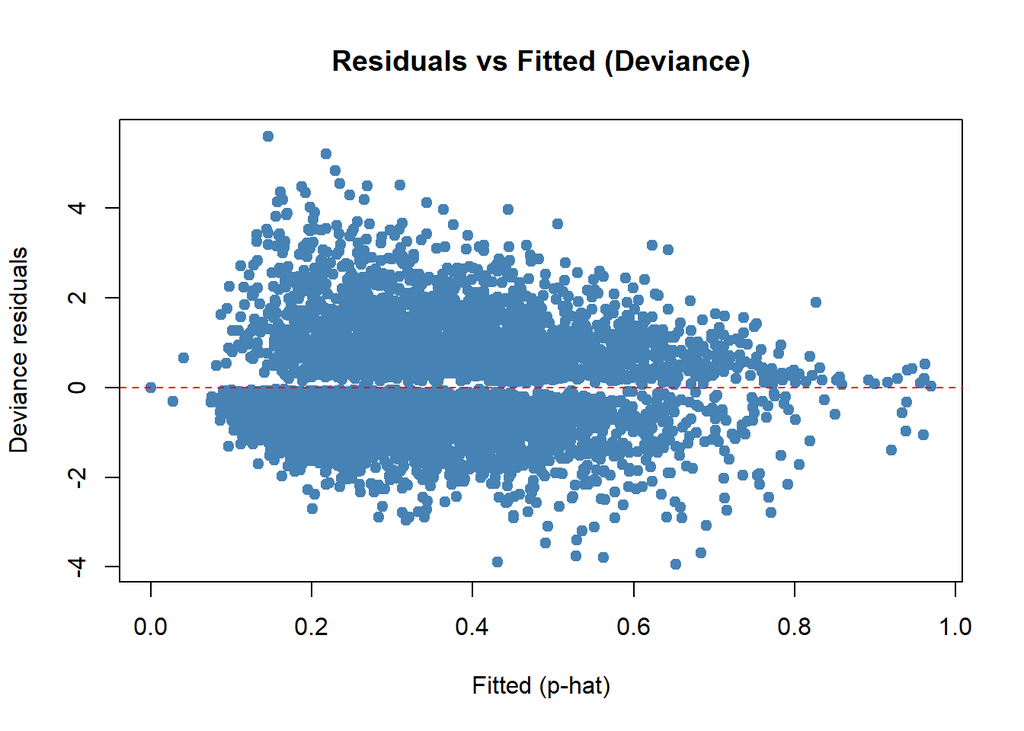

```r
res_dev <- residuals(fit_int, type = "deviance")
plot(fitted(fit_int), res_dev, xlab="Fitted (p-hat)", ylab="Deviance residuals",
     main="Residuals vs Fitted (Deviance)", pch=19, col="steelblue")
abline(h=0, lty=2, col="red")
```